# Inference Tutorial

# Introduction

The purpose of social network analysis is to investigate complex relationships and interactions amongst entities within a network. Advanced social network analysis techniques can be used to answer question such as:

- With whom will an individual develop relationships?
- How does an individual interact with others via such relationships?
- Who is central or an opinion leader in the social network to which an individual belongs?

Social network analysis techniques can be categorized as either descriptive techniques or statistical inference techniques. One of the main limitations of descriptive techniques is that it is difficult to analyze certain characteristics of social networks in a relative sense. For example, if a particular social network has a certain number of ties among the members, with descriptive methods we can hardly determine the degree to which the members of the network are densely connected. On the other hand, statistical inference techniques enable us to produce appropriate conclusions about network data that goes beyond the immediate scope of the data.

The aim of this tutorial is to give you a basic introduction to statistical inference of network data with RStudio. The tutorial will be structured as follows:

- Understanding network data in relation to statistics.
- Analysing the dataset.
- Describing one network.
- Exercise 1:
  - Univariate analysis: calculating the density of 1 network against a hypothesis.
  - Bivariate analysis: calculating the density of 2 networks against a hypothesis.
- Exercise 2:correlation between networks.
- Exercise 3: network regression.
- Conclusion

# Understanding network data in relation to statistics

Before we start, there are two essential concepts that you must understand about applying statistics to network data.

Firstly, social network analysis is about relations among actors, not about relations between variables. This is extremely important to understand because it means that rather than describing distributions of attributes of actors (or “variables), we are describing the distributions of relations among actors. Therefore, in applying statistics to network data, we are concerned with issues like the average strength of relations between actors, for example:

*“Is the strength of ties between actors in a network correlated with the centrality of the actors in the network?”*

Secondly, many of the standard inferential statistic tools that are concerned with the distribution of attributes cannot be applied directly to network data. This is because, unlike attribute analysis, the observations in network data are not independent samplings from populations. For example, in network data, we might observe Chad’s tie with Darren, while another observation might be Darren’s tie with Ryan. Network analysis says that we cannot suppose that these relations are independent because Darren is involved in two of the observations and there is a strong likelihood that we will infer another observation which depicts Chad’s tie with Ryan. Standard inferential tests assume independent observations and therefore, if we apply standard inferential statistics to observations that are not independent, it will produce seriously misleading results.

In order to overcome these challenges, when applying statistics to network data, we need to use alternative numerical approaches. These approaches are known as “bootstrapping” and permutations but for now, let’s start with the tutorial.

# Understanding the Data

This tutorial is purely for introductory purposes and so, the following sections’ objective is to walk you through two exercises which will give you a basic understanding of how to apply inferential statistics to network data.

For this tutorial, we will be using the Knoke and Knoki datasets which describes two relations; the exchange of information and the exchange of money among 10 organizations. The following code exhibits the money exchange matrix and the information exchange matrix:

```r
# Import the libraries needed to complete this tutorial
pacman::p_load(statnet,dplyr,resample,snowboot,igraph)
```

```r
# Creation of information and monetry network data. First, a matrix is created, and thereafter names are assigned to the relevant columns before being mapped to a network variable
KNOKI <-  matrix(
  c(0,1,0,0,1,0,1,0,1,0,1,0,1,1,1,0,1,1,1,0,0,1,0,1,1,1,1,0,0,1,1,1,0,0,1,0,1,0,0,0,1,1,1,1,0,0,1,1,1,1,0,0,1,0,0,0,1,0,1,0,0,1,0,1,1,0,0,0,0,0,1,1,0,1,1,0,1,0,1,0,0,1,0,0,1,0,1,0,0,0,1,1,1,0,1,0,1,0,0,0),
  nrow=10,
  ncol=10,
  byrow=T)
dimnames(KNOKI) = list(c(1,2,3,4,5,6,7,8,9,10), c("C","C","E","I","M","W","N","U","W","W"))

KNOKE <-  matrix(
  c(0,0,1,0,1,0,0,1,1,1,0,0,1,0,0,0,0,0,0,0,0,0,0,0,0,0,0,1,0,0,0,1,1,0,0,0,1,1,1,0,0,1,1,0,0,0,0,1,1,0,0,0,0,0,0,0,0,0,0,0,0,1,0,0,0,0,0,1,0,0,0,0,0,0,0,0,0,0,1,1,0,0,1,0,0,0,0,1,0,0,0,0,0,0,0,0,0,0,0,0),
  nrow=10,
  ncol=10,
  byrow=T)

dimnames(KNOKE) = list(c(1,2,3,4,5,6,7,8,9,10), c("C","C","E","I","M","W","N","U","W","W"))
```

```r
#Display the matrices
print("Matrix #1: KNOKI")
```

```
## [1] "Matrix #1: KNOKI"
```

```r
KNOKI #information
```

```
##    C C E I M W N U W W
## 1  0 1 0 0 1 0 1 0 1 0
## 2  1 0 1 1 1 0 1 1 1 0
## 3  0 1 0 1 1 1 1 0 0 1
## 4  1 1 0 0 1 0 1 0 0 0
## 5  1 1 1 1 0 0 1 1 1 1
## 6  0 0 1 0 0 0 1 0 1 0
## 7  0 1 0 1 1 0 0 0 0 0
## 8  1 1 0 1 1 0 1 0 1 0
## 9  0 1 0 0 1 0 1 0 0 0
## 10 1 1 1 0 1 0 1 0 0 0
```

```r
print("Matrix #2: KNOKE")
```

```
## [1] "Matrix #2: KNOKE"
```

```r
KNOKE #money
```

```
##    C C E I M W N U W W
## 1  0 0 1 0 1 0 0 1 1 1
## 2  0 0 1 0 0 0 0 0 0 0
## 3  0 0 0 0 0 0 0 1 0 0
## 4  0 1 1 0 0 0 1 1 1 0
## 5  0 1 1 0 0 0 0 1 1 0
## 6  0 0 0 0 0 0 0 0 0 0
## 7  0 1 0 0 0 0 0 1 0 0
## 8  0 0 0 0 0 0 0 0 1 1
## 9  0 0 1 0 0 0 0 1 0 0
## 10 0 0 0 0 0 0 0 0 0 0
```

```r
#Below, we have created networks from the matrices
KNOKI.n <- as.network(KNOKI)
KNOKE.n <- as.network(KNOKE)
```

As you can see, network data matrices consist of a square array of measurements. The rows of the array are the same set of observations, while each cell of the array describes a relationship between actors. In our dataset, each cell represents either the exchange of money or information between two organisations as a 1 or no exchange as a 0. By comparing rows of the array we can see which actors are similar to which other actors in whom they choose to exchange information or money. By looking at the columns, we can see who is similar to whom in terms of being chosen by others. This helps us to see which actors have similar positions in the network which brings us to the first major emphasis of network analysis: how are actors located or embedded within the overall network?

However, a network analyst will also look at the data in a more holistic way. For example, they may notice that there are about equal numbers of ones and zeros in the matrix which suggests that there is a moderate density of liking overall. However, the analyst may want to test prior made hypotheses about the density or mean tie strength of a network. For example, we might want to test:

- Whether the hypothesis that, the proportion of binary ties present, differs from .50?
- Whether the hypothesis that, the average strength of a valued tie, differs from 3?

This will bring us to the first exercise which involves finding the degree to which the members of a network are densely connected.

# Decribing one Network

Before we start with the first exercise, let’s do an in-depth analysis of one of the matrices, we will use the Knoke matrix, in order to solidify our understanding of the various statistical values which we may observe.

```r
KNOKE
```

```
##    C C E I M W N U W W
## 1  0 0 1 0 1 0 0 1 1 1
## 2  0 0 1 0 0 0 0 0 0 0
## 3  0 0 0 0 0 0 0 1 0 0
## 4  0 1 1 0 0 0 1 1 1 0
## 5  0 1 1 0 0 0 0 1 1 0
## 6  0 0 0 0 0 0 0 0 0 0
## 7  0 1 0 0 0 0 0 1 0 0
## 8  0 0 0 0 0 0 0 0 1 1
## 9  0 0 1 0 0 0 0 1 0 0
## 10 0 0 0 0 0 0 0 0 0 0
```

Firstly, it is important to note that this particular dataset is asymmetric and binary and the data which we are observing is the relations between the actors. So, in each matrix we have 10 x 10 = 100 observations or cases. For many analyses, the ties of actors with themselves (the main diagonal) are not meaningful and so there is actually N x N-1 = 90 observations. If the data were symmetric (Xij = Xji), half of the observations would be redundant and so there would be N x N-1 / 2 = 45 observations, however, this is not the case for our dataset.

The first thing we are going to do is summarise some of the most basic characteristics of the distribution of these scores. To do this, we are going to generate the most commonly used statistical measures for the Knoke matrix.

```r
# Remove diagonal because it throws off any matrix calculations
KNOKI.m <- diag.remove(as.sociomatrix(KNOKI.n))
KNOKE.m <- diag.remove(as.sociomatrix(KNOKE.n))
```

```r
# Summary run to gain a better insight of the matrix
summary(KNOKE.n)
```

```
## Network attributes:
##   vertices = 10
##   directed = TRUE
##   hyper = FALSE
##   loops = FALSE
##   multiple = FALSE
##   bipartite = FALSE
##  total edges = 22
##    missing edges = 0
##    non-missing edges = 22
##  density = 0.2444444
##
## Vertex attributes:
##   vertex.names:
##    character valued attribute
##    10 valid vertex names
##
## No edge attributes
##
## Network adjacency matrix:
##   C C E I M W N U W W
## C 0 0 1 0 1 0 0 1 1 1
## C 0 0 1 0 0 0 0 0 0 0
## E 0 0 0 0 0 0 0 1 0 0
## I 0 1 1 0 0 0 1 1 1 0
## M 0 1 1 0 0 0 0 1 1 0
## W 0 0 0 0 0 0 0 0 0 0
## N 0 1 0 0 0 0 0 1 0 0
## U 0 0 0 0 0 0 0 0 1 1
## W 0 0 1 0 0 0 0 1 0 0
## W 0 0 0 0 0 0 0 0 0 0
```

```r
# Summary run to gain a better insight of the matrix
summary(KNOKE.m)
```

```
##        C           C                E                I
##  Min.   :0   Min.   :0.0000   Min.   :0.0000   Min.   :0
##  1st Qu.:0   1st Qu.:0.0000   1st Qu.:0.0000   1st Qu.:0
##  Median :0   Median :0.0000   Median :1.0000   Median :0
##  Mean   :0   Mean   :0.3333   Mean   :0.5556   Mean   :0
##  3rd Qu.:0   3rd Qu.:1.0000   3rd Qu.:1.0000   3rd Qu.:0
##  Max.   :0   Max.   :1.0000   Max.   :1.0000   Max.   :0
##  NA's   :1   NA's   :1        NA's   :1        NA's   :1
##        M                W           N                U
##  Min.   :0.0000   Min.   :0   Min.   :0.0000   Min.   :0.0000
##  1st Qu.:0.0000   1st Qu.:0   1st Qu.:0.0000   1st Qu.:0.0000
##  Median :0.0000   Median :0   Median :0.0000   Median :1.0000
##  Mean   :0.1111   Mean   :0   Mean   :0.1111   Mean   :0.6667
##  3rd Qu.:0.0000   3rd Qu.:0   3rd Qu.:0.0000   3rd Qu.:1.0000
##  Max.   :1.0000   Max.   :0   Max.   :1.0000   Max.   :1.0000
##  NA's   :1        NA's   :1   NA's   :1        NA's   :1
##        W                W
##  Min.   :0.0000   Min.   :0.0000
##  1st Qu.:0.0000   1st Qu.:0.0000
##  Median :0.0000   Median :0.0000
##  Mean   :0.4444   Mean   :0.2222
##  3rd Qu.:1.0000   3rd Qu.:0.0000
##  Max.   :1.0000   Max.   :1.0000
##  NA's   :1        NA's   :1
```

By looking at the data we already know that the number of observations is 90 which range from a minimum score of 0 to a maximum score of 1. By analysing the summary of the matrix we can observe that the sum of the ties (total edges) is 22 and the average value (density) of the ties is 22/90 = 0.244. Due to the fact that our relations have been coded as a “dummy” variables (0 for no relation, 1 for a relation), the mean is also the proportion of possible ties that are present (or the density) within the network.

Adding onto this, we might also want to examine the distribution of ties for each actor, opposed to the distribution of ties for the entire network.

```r
#Univariate descriptive statistics for Knoke information network rows
mat <- t(data_frame(
mean = round(apply(KNOKI.m, 1, mean, na.rm = T),3),
stdev = round(apply(KNOKI.m, 1, sd, na.rm = T),3),
sum = round(apply(KNOKI.m, 1, sum, na.rm = T),3),
var = round(apply(KNOKI.m, 1, var, na.rm = T),3),
min = round(apply(KNOKI.m, 1, min, na.rm = T),3),
max = round(apply(KNOKI.m, 1, max, na.rm = T),3)
)) %>% data.frame()
colnames(mat) <- colnames(KNOKI.m)
mat
```

```
##           C     C     E     I     M     W     N     U     W     W
## mean  0.444 0.778 0.667 0.444 0.889 0.333 0.333 0.667 0.333 0.556
## stdev 0.527 0.441 0.500 0.527 0.333 0.500 0.500 0.500 0.500 0.527
## sum   4.000 7.000 6.000 4.000 8.000 3.000 3.000 6.000 3.000 5.000
## var   0.278 0.194 0.250 0.278 0.111 0.250 0.250 0.250 0.250 0.278
## min   0.000 0.000 0.000 0.000 0.000 0.000 0.000 0.000 0.000 0.000
## max   1.000 1.000 1.000 1.000 1.000 1.000 1.000 1.000 1.000 1.000
```

```r
#Univariate descriptive statistics for Knoke information network columns
mat <- t(data_frame(
mean = round(apply(KNOKI.m, 2, mean, na.rm = T),3),
stdev = round(apply(KNOKI.m, 2, sd, na.rm = T),3),
sum = round(apply(KNOKI.m, 2, sum, na.rm = T),3),
var = round(apply(KNOKI.m, 2, var, na.rm = T),3),
min = round(apply(KNOKI.m, 2, min, na.rm = T),3),
max = round(apply(KNOKI.m, 2, max, na.rm = T),3)
)) %>% data.frame()
colnames(mat) <- colnames(KNOKI.m)
mat
```

```
##           C     C     E     I     M     W N     U     W     W
## mean  0.556 0.889 0.444 0.556 0.889 0.111 1 0.222 0.556 0.222
## stdev 0.527 0.333 0.527 0.527 0.333 0.333 0 0.441 0.527 0.441
## sum   5.000 8.000 4.000 5.000 8.000 1.000 9 2.000 5.000 2.000
## var   0.278 0.111 0.278 0.278 0.111 0.111 0 0.194 0.278 0.194
## min   0.000 0.000 0.000 0.000 0.000 0.000 1 0.000 0.000 0.000
## max   1.000 1.000 1.000 1.000 1.000 1.000 1 1.000 1.000 1.000
```

It is helpful to note that if we were working with valued data, rather than binary data, the measure of variability would be more informative across actors. This is because the variability of binary data is strictly a function of its mean. The main objective of this section was to emphasise the first essential concept that when we use statistics to describe network data, we are describing properties of the distribution of relations (or ties among actors) rather than properties of the distribution of attributes across actors.

# Exercise One: Univariate Analaysis

Now that we have a better understanding of a single network, and the general statistical measures of that network, we can begin with the first exercise. As previously mentioned, network analysts are usually interested in a more holistic view of the network which usually involves the density, or average tie strength, of the network. It is typical for an analyst to want to prove or disprove a theory about the density of a network and for this we need to create a hypothesis (for the purpose of this exercise we will be working with the Knoki matrix):

*Hypothesis: “Let’s suppose that we think that all organisations have the tendency to want to directly distribute information to all other organisations in the network, as a way of legitimizing themselves.”*

This hypothesis suggests that all the organisations will exchange information with all other organisations and therefore each cell in the matrix will = 1. Therefore, if this hypothesis/theory is correct, then the density of the Knoki network should be 1.0. We are now able to compare the true value of the network density, or average tie strength, against a test value (density = 1.0).

```r
# In this instance, Binary Networks use density for a degree of central tendency. When creating predicitions of network densities, creating the hypothesus around an expected density is necessary and then to measure vairation around the expected and actual density

summary(KNOKI.n)
```

```
## Network attributes:
##   vertices = 10
##   directed = TRUE
##   hyper = FALSE
##   loops = FALSE
##   multiple = FALSE
##   bipartite = FALSE
##  total edges = 49
##    missing edges = 0
##    non-missing edges = 49
##  density = 0.5444444
##
## Vertex attributes:
##   vertex.names:
##    character valued attribute
##    10 valid vertex names
##
## No edge attributes
##
## Network adjacency matrix:
##   C C E I M W N U W W
## C 0 1 0 0 1 0 1 0 1 0
## C 1 0 1 1 1 0 1 1 1 0
## E 0 1 0 1 1 1 1 0 0 1
## I 1 1 0 0 1 0 1 0 0 0
## M 1 1 1 1 0 0 1 1 1 1
## W 0 0 1 0 0 0 1 0 1 0
## N 0 1 0 1 1 0 0 0 0 0
## U 1 1 0 1 1 0 1 0 1 0
## W 0 1 0 0 1 0 1 0 0 0
## W 1 1 1 0 1 0 1 0 0 0
```

```r
#If one wanted to pbtain only the network density however, use the following
network.density(KNOKI.n)
```

```
## [1] 0.5444444
```

We can see that this theory is not true because the true network density of Knoki is not equal to 1.0, it is equal to 0.544. However, perhaps the difference between what we see (density = 0.544) and what the theory predicts (density = 1.0) is due to random variation (which occurs when the information is collected). Therefore, we need to find a way to ask the data to convince us that we can be confident in rejecting the hypothesis. To do this, we need to be able to compare the network to a randomly generated network of the same size. By comparing our network to a randomly generated network, we can determine the degree to which our network has the same density compared to a network generated by chance, allowing us to reduce the effect of random variation. This brings us back to the numerical approaches of “bootstrapping” and permutations.

```r
# In order to produce a sample distribution of density measures, we use bootstrapping to recreate sample networks and thereafter re-calcukate density

set.seed(1)
B <- 5000
KNOKI.boot <- vertboot(KNOKI, B)

densities <- sapply(1:B, function(x)
  graph.density(graph_from_adjacency_matrix(KNOKI.boot[[x]])))
mean(densities)
```

```
## [1] 0.6049511
```

```r
### NOT GETTING THE RIGHT OUTPUT HERE, CHECK CATHS CODE ###

#Maybe this?
t.test(KNOKI)
```

```
##
##  One Sample t-test
##
## data:  KNOKI
## t = 9.7528, df = 99, p-value = 3.787e-16
## alternative hypothesis: true mean is not equal to 0
## 95 percent confidence interval:
##  0.3903093 0.5896907
## sample estimates:
## mean of x
##      0.49
```

Remember, the reason why we use bootstrapping rather than the classical formula for the standard error of a mean (s / sqr(N)) is because the classical formula is based on the notion that all observations are independent, which is not the case for network data. If we used the standard inferential formulas we would observe unrealistically small values for our network data which would result in two kinds of errors, the false positive or rejecting the null hypothesis when we shouldn’t.

# Exercise One: Bivariate Analysis

In the above example we were working with univariate analysis (analysis on one network), we will now move on to bivariate analysis (analysis of two networks). Bivariate analysis is important because it enables network analysts to continue to infer holistic information about the network. In fact, bivariate analysis brings up the second major emphasis of network analysis: seeing how the whole pattern of individual choices gives rise to more holistic patterns. The basic question of bivariate analysis on network data is:

*“Do the pattern of ties for one relation among a set of actors align with the pattern of ties for another relation among the same set of actors?”*

In summary, this question is asking whether the relations between two networks, with the same set of actors, correlate or not? We can answer this by analysing different kinds of relations within the network, such as:

- Does the central tendency (mean) of one relation differ significantly from the central tendency (mean) of another?
- If we know that the relation of one type exists between two actors, how much does this increase (or decrease) the likelihood that the relation of another type exists between them?

We will work through the first question now but the following question will be covered in exercise 2 of this tutorial. Let’s relate the first question to our networks. Our networks describe the money and information exchange among organisations (the 2 separate matrices: Knoke and Knoki). Therefore, in relation to the first question, we are asking:

*“Which ties are more prevalent: money exchange ties or information exchange ties?”*

In other words, “which network has the higher density?”. This question is answered by analysing the densities of both networks and comparing them. However, similarly to the univariate analysis, we must make use of “bootstrapping” to ensure that our observation is accurate and not a result of random variation. We can already observe that the density of the information exchange matrix (0,544) is higher than the density of the monetary exchange matrix (0,244). Therefore, our hypothesis should be:

*“Information exchange ties are more prevalent than monetary exchange ties”.*

```r
# Both compared to randomly generated matrices
both.ttest <- t.test(KNOKI, KNOKE, paired = TRUE)
both.ttest
```

```
##
##  Paired t-test
##
## data:  KNOKI and KNOKE
## t = 4.1597, df = 99, p-value = 6.793e-05
## alternative hypothesis: true difference in means is not equal to 0
## 95 percent confidence interval:
##  0.1412072 0.3987928
## sample estimates:
## mean of the differences
##                    0.27
```

```r
### NOT GETTING THE RIGHT OUTPUT HERE, CHECK CATHS CODE ###
```

# Exercise Two: Correlation Between Networks

The objective of this exercise is to come to a conclusion about whether the relations of the two networks correlate or not. We will do this by answering the previously stated question: “If we know that the relation of one type exists between two actors, how much does this increase (or decrease) the likelihood that the relation of another type exists between them?”. In other words, if two actors have a strong tie of one type, are they also likely to have a strong tie of another? Let’s start by relating this question to our networks:

*“If two organizations exchange information, how likely is it that they will also exchange money?”*

If organizations exchange information, this may create a sense of trust, making monetary exchange relations more likely. This could also be inferred the other way, if two organisations exchange money, this may facilitate more open communications and, as a result, the exchange of information. Therefore, we might hypothesise that:

*“The matrix of information relations would be positively correlated with the matrix of monetary relations”.*

Otherwise stated, pairs that engage in one type of exchange are more likely to engage in the other. A positive correlation might be true, but it is possible that we could also observe:

- A negative correlation- where money flows in one direction and information in the other direction.
- No correlation- the two relations have nothing to do with one another.

```r
# Correlating both networks

gcor(list(KNOKE, KNOKI))
```

```
##             1           2
## 1  1.00000000 -0.05076062
## 2 -0.05076062  1.00000000
```

```r
# Here, a quadratic assignment procedure (QAP) hypothesis test is performed. In a qaptest, an arbitrary graph-level statistic(computed on the first argument, by the second) is tested against a qap null hypothesis

(KNOK.cor <- qaptest(list(KNOKE, KNOKI), gcor, g1=1, g2=2, reps=2000))
```

```
##
## QAP Test Results
##
## Estimated p-values:
##  p(f(perm) >= f(d)): 0.722
##  p(f(perm) <= f(d)): 0.427
```

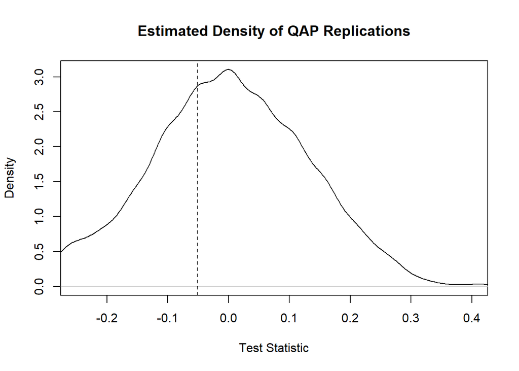

```r
# Plotting QAP correlated networks

plot(KNOK.cor, xlim=c(-0.25, 0.4))
```

```r
# Performance of Standard Multiple Regression Analysis

nl<-netlm(KNOKE.n, KNOKI.n, reps=1000)
summary(nl)
```

```
##
## OLS Network Model
##
## Residuals:
##         0%        25%        50%        75%       100%
## -0.2682927 -0.2682927 -0.2244898 -0.2244898  0.7755102
##
## Coefficients:
##             Estimate    Pr(<=b) Pr(>=b) Pr(>=|b|)
## (intercept)  0.26829268 0.960   0.040   0.040
## x1          -0.04380289 0.298   0.703   0.728
##
## Residual standard error: 0.4341 on 88 degrees of freedom
## Multiple R-squared: 0.002577     Adjusted R-squared: -0.008758
## F-statistic: 0.2273 on 1 and 88 degrees of freedom, p-value: 0.6347
##
##
## Test Diagnostics:
##
##  Null Hypothesis: qap
##  Replications: 1000
##  Coefficient Distribution Summary:
##
##        (intercept)        x1
## Min      -0.644785 -4.268461
## 1stQ      1.173858 -0.968293
## Median    1.960766  0.010822
## Mean      1.973001  0.002219
## 3rdQ      2.682541  0.990292
## Max       6.502623  3.672551
```

```r
# QAP Logistic Regression

nlog<-netlogit(KNOKE.n, KNOKI.n,reps=1000)
summary(nlog)
```

```
##
## Network Logit Model
##
## Coefficients:
##             Estimate   Exp(b)    Pr(<=b) Pr(>=b) Pr(>=|b|)
## (intercept) -1.0033021 0.3666667 0.083   0.917   0.083
## x1          -0.2363888 0.7894737 0.339   0.664   0.747
##
## Goodness of Fit Statistics:
##
## Null deviance: 124.7665 on 90 degrees of freedom
## Residual deviance: 99.87552 on 88 degrees of freedom
## Chi-Squared test of fit improvement:
##   24.89098 on 2 degrees of freedom, p-value 3.935438e-06
## AIC: 103.8755    BIC: 108.8751
## Pseudo-R^2 Measures:
##  (Dn-Dr)/(Dn-Dr+dfn): 0.2166487
##  (Dn-Dr)/Dn: 0.1995005
## Contingency Table (predicted (rows) x actual (cols)):
##
##      0    1
## 0   68   22
## 1    0    0
##
##  Total Fraction Correct: 0.7555556
##  Fraction Predicted 1s Correct: NaN
##  Fraction Predicted 0s Correct: 0.7555556
##  False Negative Rate: 1
##  False Positive Rate: 0
##
## Test Diagnostics:
##
##  Null Hypothesis: qap
##  Replications: 1000
##  Distribution Summary:
##
##        (intercept)       x1
## Min       -3.68118 -3.83772
## 1stQ      -2.21812 -0.96995
## Median    -1.59401  0.01094
## Mean      -1.57666 -0.06984
## 3rdQ      -0.95892  0.99109
## Max        1.87905  3.32733
```

```r
summary(KNOK.cor)
```

```
##
## QAP Test Results
##
## Estimated p-values:
##  p(f(perm) >= f(d)): 0.722
##  p(f(perm) <= f(d)): 0.427
##
## Test Diagnostics:
##  Test Value (f(d)): -0.05076062
##  Replications: 2000
##  Distribution Summary:
##      Min:     -0.517989
##      1stQ:    -0.1026749
##      Med:     0.00115365
##      Mean:    -0.002610134
##      3rdQ:    0.1049822
##      Max:     0.4164678
```

- The Pearson coefficient is a standard measure when both matrices have valued relations (our dataset does not have any valued relations).
- Simple matching and the Jaccard coefficient are reasonable measures when both relations are binary (this relates to our dataset).
- Gamma would be a reasonable choice if one or both relations were measured on an ordinal scale.
- The Hamming distance is a measure of dissimilarity or distance between the scores in one matrix and the scores in the other.

# Exercise Three: Network Regression

Suppose we want to make the following hypothesis:

*“Institutionally similar organizations are more likely to exchange information”.*

Therefore we want to be able to predict which of the organisations sent information to which others. To do this, we are going to treat the information exchange network (Knoki) as our dependant network with N = 90 (there are 90 observations) and we are going to create a new matrix which we will treat as one of our independent networks (linear regression may be extended to using more than one independent variable). Use the following code to make the new matrix:

```r
# Creating a network coding each element as "1" if both are private or both are non-private, and a "0" if they are of mixed types

KNOKP.n <-  matrix(
  c(0,1,0,1,0,0,0,1,0,1,1,0,0,1,0,0,0,1,0,1,0,0,0,0,1,1,1,0,1,0,1,1,0,0,0,0,0,1,0,1,0,0,1,0,0,1,1,0,1,0,0,0,1,0,1,0,1,0,1,0,0,0,1,0,1,1,0,0,1,0,1,1,0,1,0,0,0,0,0,1,0,0,1,0,1,1,1,0,0,0,1,1,0,1,0,0,0,1,0,0),
  nrow=10,
  ncol=10,
  byrow=T)

dimnames(KNOKP.n) = list(c(1,2,3,4,5,6,7,8,9,10), c("C","C","E","I","M","W","N","U","W","W"))
```

```r
#Performance of Standard Multiple Regression analysis by regressing each element in the network on its corresponding elements in the information network

nl_p<-netlm(KNOKI.n, KNOKP.n, reps=1000)
summary(nl_p)
```

```
##
## OLS Network Model
##
## Residuals:
##     0%    25%    50%    75%   100%
## -0.575 -0.520  0.425  0.480  0.480
##
## Coefficients:
##             Estimate Pr(<=b) Pr(>=b) Pr(>=|b|)
## (intercept) 0.520    1.000   0.000   0.000
## x1          0.055    0.609   0.392   0.651
##
## Residual standard error: 0.5029 on 88 degrees of freedom
## Multiple R-squared: 0.003011     Adjusted R-squared: -0.008318
## F-statistic: 0.2658 on 1 and 88 degrees of freedom, p-value: 0.6075
##
##
## Test Diagnostics:
##
##  Null Hypothesis: qap
##  Replications: 1000
##  Coefficient Distribution Summary:
##
##        (intercept)       x1
## Min        2.21472 -2.51981
## 1stQ       3.41250 -0.75118
## Median     4.06858  0.09360
## Mean       4.09223  0.03908
## 3rdQ       4.73625  0.51557
## Max        7.31166  2.26263
```

# Conclusion

This brings us to the end of the tutorial. Let’s summarise what we have learnt:

- Two essential concepts about network data:
  - Network analysis is about relations among actors, NOT about relations between variables.
  - Observations in network data are NOT independent samplings from populations.
- Understanding matrices and binary data compared to valued data (the variability of binary data is strictly a function of its mean).
- Univariate analysis:
  - Comparing 1 network to randomly generated networks of the same size to prove/disprove a hypothesis.
- Bivariate analysis:
  - Comparing 2 networks to randomly generated networks of the same size to answer the question: *“Does mean/density of one relation differ significantly from the mean/density of another?”.*
  - Correlating 2 networks with the same set of actors to answer the question: *“If we know that the relation of one type exists between two actors, how much does this increase (or decrease) the likelihood that the relation of another type exists between them?”.*
- Network regression:
  - Being able to predict one relation knowing the other.

```r
# Is density == mean for a network?
mean(KNOKI.m,na.rm = T) == network.density(KNOKI.n)
```

```
## [1] TRUE
```

```r
# Valuating Univariate Descriptive Statistics for KNOKI (Information) Network Columns

mat <- t(tibble(
mean = round(apply(KNOKI.m, 2, mean, na.rm = T),3),
stdev = round(apply(KNOKI.m, 2, sd, na.rm = T),3),
sum = round(apply(KNOKI.m, 2, sum, na.rm = T),3),
var = round(apply(KNOKI.m, 2, var, na.rm = T),3),
min = round(apply(KNOKI.m, 2, min, na.rm = T),3),
max = round(apply(KNOKI.m, 2, max, na.rm = T),3)
)) %>% data.frame()
colnames(mat) <- colnames(KNOKI.m)
mat
```

```
##           C     C     E     I     M     W N     U     W     W
## mean  0.556 0.889 0.444 0.556 0.889 0.111 1 0.222 0.556 0.222
## stdev 0.527 0.333 0.527 0.527 0.333 0.333 0 0.441 0.527 0.441
## sum   5.000 8.000 4.000 5.000 8.000 1.000 9 2.000 5.000 2.000
## var   0.278 0.111 0.278 0.278 0.111 0.111 0 0.194 0.278 0.194
## min   0.000 0.000 0.000 0.000 0.000 0.000 1 0.000 0.000 0.000
## max   1.000 1.000 1.000 1.000 1.000 1.000 1 1.000 1.000 1.000
```

```r
# Valuating Univariate Descriptive Statistics for KNOKI (Information) Network Rows

mat <- t(tibble(
mean = round(apply(KNOKI.m, 1, mean, na.rm = T),3),
stdev = round(apply(KNOKI.m, 1, sd, na.rm = T),3),
sum = round(apply(KNOKI.m, 1, sum, na.rm = T),3),
var = round(apply(KNOKI.m, 1, var, na.rm = T),3),
min = round(apply(KNOKI.m, 1, min, na.rm = T),3),
max = round(apply(KNOKI.m, 1, max, na.rm = T),3)
)) %>% data.frame()
colnames(mat) <- colnames(KNOKI.m)
mat
```

```
##           C     C     E     I     M     W     N     U     W     W
## mean  0.444 0.778 0.667 0.444 0.889 0.333 0.333 0.667 0.333 0.556
## stdev 0.527 0.441 0.500 0.527 0.333 0.500 0.500 0.500 0.500 0.527
## sum   4.000 7.000 6.000 4.000 8.000 3.000 3.000 6.000 3.000 5.000
## var   0.278 0.194 0.250 0.278 0.111 0.250 0.250 0.250 0.250 0.278
## min   0.000 0.000 0.000 0.000 0.000 0.000 0.000 0.000 0.000 0.000
## max   1.000 1.000 1.000 1.000 1.000 1.000 1.000 1.000 1.000 1.000
```